# ct: Unifying Camera Trap Data Infrastructure in R

Author

Affiliation

Stanislas Mahussi Gandaho

Laboratory of Applied Ecology, University of Abomey-Calavi, Benin

Published

2025-09-19

# Executive Summary

The [ct](https://stangandaho.github.io/ct/index.html) project (initially maimer) addresses a critical gap in ecological research by unifying the fragmented camera trap data ecosystem in R. Camera traps produce vast datasets that are central to wildlife monitoring and conservation, yet researchers must navigate multiple disconnected tools and standards, creating inefficiency and barriers to adoption. The goal of `ct` package is to provide an integrated, tidyverse-friendly workflow that streamlines data import, cleaning, visualization, and analysis, making advanced methods more accessible to ecologists and conservation practitioners.

With support from the R Consortium, we have successfully completed Milestone 1, which delivered a core integration layer connecting `ct` to key packages like `activity`, `camtraptor`, `Distance`, and `camtrapDensity`, while ensuring compatibility with the Camera Trap Data Package (Camtrap DP) standard. This work laid the foundation for reproducible workflows for data processing, analysis, modeling, and attracted significant interest from the community, including a well-attended [webinar](https://naben.org/evenement/estimation-de-la-densite-de-population-avec-camera-trap/) (recording [here](https://youtu.be/QoNXDUGiLSk?t=736)) with 172 attendees.

This proposal seeks support for the remaining two milestones:

- *Milestone 2:* deliver deep learning–based animal detection, streamlined metadata tools, and utilities for building analysis-ready datasets from images/videos.
- *Milestone 3:* create vignettes, articles, complete user testing, and consider submitting the package to rOpenSci for peer review before sending it to CRAN.

The total requested budget is $8,000, supporting six months of part-time development.

# Signatories

This proposal is supported by community of researchers and practitioners committed to improving camera trap data workflows in R. Letters of support have been received from the Laboratory of Applied Ecology, University of Abomey-Calavi, Benin.

## Project team

The ct project will be led by me, ecological data scientist with extensive experience in ecological data management, statistical modeling, and open-source software development. I’m the creator and maintainer of [nimo](https://nimo.naben.org/), and [redlist](https://stangandaho.github.io/redlist/index.html) (now on CRAN), as well as software tools for machine learning and ecological monitoring such as [Declas](https://github.com/stangandaho/declas). My expertise in R package development, computer vision, and reproducible research workflows ensures that the project will be delivered to high technical and usability standards.

Prof. Marcus Rowcliffe (Zoological Society of London) and Damiano Oldoni (Research Institute for Nature and Forest, Belgium) will remain members of the project team, providing technical input and testing support. Their continued involvement guarantees that the package stays relevant to the broader camera trap data community.

## Contributors

[Dr. Sylvestre Djagoun](https://scholar.google.com/citations?hl=en&user=VE0PwzAAAAAJ&view_op=list_works&sortby=pubdate)

## Consulted

[Yanina Bellini Saibene](https://www.linkedin.com/in/yabellini/)

# The Problem

Camera traps are central to modern ecological research, conservation monitoring, and wildlife management, generating vast datasets that must be processed, summarized, and analyzed efficiently. Processing and analyzing camera trap data in R often requires multiple steps, from cleaning raw data to statistical modeling and visualization. However, the current R ecosystem for camera trap data remains fragmented. Researchers often combine multiple packages such as *camtrapR* (Niedballa et al. 2016) for data management, *activity* for animal diel activity patterns (Rowcliffe 2023), *unmarked* or *secr* for occupancy and capture–recapture modeling (Fiske and Chandler 2011; Kellner et al. 2023; Efford 2024). New methodologies, such as deep learning-assisted species identification, are often siloed in standalone tools *CameraTrapDetectoR* (Tabak et al. 2022). The absence of a cohesive pipeline hinders innovation. Additionally, no existing R package natively integrates MegaDetector (Beery, Morris, and Yang 2019), for object detection, providing full support for both images and videos, and offers a Shiny application that combines automated computer-vision processing with manual annotation and metadata management in a single workflow. MegaDetector’s versatility makes it an appealing option for a wide variety of camera trap projects, and its use and popularity have been rapidly growing worldwide (Leorna and Brinkman 2022). By integrating existing tools with novel approaches—such as those under development in the *ct* package, we plan to create an “all-in-one” platform that streamlines workflows, reduces redundancy, and democratizes access to advanced analytical methods. The package aims to provide a modern, tidyverse-friendly workflow for camera trap data analysis. Using tidy evaluation principles, it enables users to efficiently manipulate and transform datasets. Additionally, it integrates seamlessly with ggplot2 (Wickham 2016), allowing users to generate highly customizable visualizations. This project will directly benefit ecologists, conservationists, and educators who rely on R for reproducible research but currently face unnecessary complexity in managing camera trap data.

# The proposal

During the first three months, we will focus on expanding the `ct` package by integrating deep learning–assisted outlier animal detection for both images and videos, leveraging existing computer vision models such as [MegaDetector](https://microsoft.github.io/CameraTraps/megadetector/). To improve accessibility, we will develop a user-friendly GUI that enables users to automate animal identification, extract relevant metadata, and generate well-structured datasets for analysis. The interface will allow users to customize and add tags such as animal sex, life stage, and other attributes, streamlining the process of organizing and preparing data for downstream research.  
In the final three months, we will prioritize testing and and creating detailed vignettes and articles covering common workflows, including data transformation, image and video processing, density and abundance estimation, and result interpretation. These resources will be designed to reduce the learning curve and facilitate adoption across diverse research groups.

## Overview

The `ct` package addresses the critical need for unified, reproducible, and accessible camera trap data workflows in R. By integrating deep learning–assisted animal detection, a user-friendly graphical interface, and comprehensive documentation, this project will bridge the gap between advanced analytical tools and practical field applications. The proposed enhancements will empower ecologists, conservationists, and citizen scientists to efficiently process, annotate, and analyze camera trap data with flexibility.

## Detail

Building on the existing foundation of the `ct` package—which already provides robust tools for data cleaning, validation, visualization, summary analysis, and density estimation—this project will focus on two main deliverables:

1. **Automated annotation:** develop and integrate a deep learning-assisted pipeline within a GUI to automate animal identification in images and videos using [MegaDetector model](https://microsoft.github.io/CameraTraps/model_zoo/megadetector/). The GUI will enable users to upload data, run detection models, edit results, add attributes/tags (e.g., species, sex, life stage).
2. **Comprehensive vignette and article:** create detailed, workflow-based documentation covering data transformation, image/video processing, density and abundance estimation, interpretation of results, etc. These resources will be accessible to users of all skill levels and will promote reproducibility and best practices.

### Minimum Viable Product

The MVP will consist of:

- A basic Shiny-based app enabling users to upload images, run detection, and export annotated datasets from the package.
- At least one end-to-end article demonstrating the workflow from raw data to analysis-ready output.

### Architecture

The high-level architecture of ct package look like the diagram below. Orange boxes represent the core components of the project proposal.

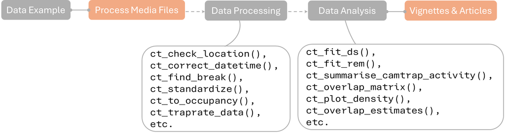

### Assumptions

We assume that we are in good health during the execution period. Otherwise technically, there is no way to make the project invalid.

### External dependencies

- [MegaDetector](https://microsoft.github.io/CameraTraps/model_zoo/megadetector/) pre-trained model model.
- [Exiftool](https://exiftool.org/)

# Project plan

## Start-up phase

The project is currently underway and has received support from the R Consortium for the first grant cycle (25-ISC-1-04). The project’s GitHub repository can be found [here](https://github.com/stangandaho/ct)

## Technical delivery

- *Month 1:* Integrate [MegaDetector (v6)](https://microsoft.github.io/CameraTraps/megadetector/) with the *ct* package, providing R functions to run detections on images and videos.
- *Month 2:* Develop a prototype Shiny application included within the package for image/video upload, automated detection, and manual annotation.
- *Month 3:* Expand the Shiny app (still shipped as part of the package) to support metadata editing, species tagging, and export of fully annotated datasets.
- *Month 4:* Conduct extensive unit testing with real-world datasets for most package functions.
- *Month 5:* Develop comprehensive vignettes and articles covering end-to-end workflows.
- *Month 6:* Finalize documentation, prepare dissemination materials, and submit delivery blog post.

## Other aspects

The project is released under MIT license. All code is hosted on [GitHub](https://github.com/stangandaho/ct). Project progress and results will be publicized through:

- Delivery blog posts on the R Consortium blog.
- Social media (at this time on [LinkedIn](https://www.linkedin.com/in/stangandaho/?locale=en_US)) updates and ISC meetings.
- Vignettes and articles will be published on the package [website](https://stangandaho.github.io/ct/index.html).

## Budget & funding plan

The project will progress through three well-defined milestones, each with dedicated budget allocations.

- *Milestone 1: Core Integration Layer (Completed)*  
  This milestone established the foundation of the project by developing standardized interfaces to connect `ct` with other packages. These integration enable smooth data exchange between packages and provide users with a consistent workflow. Key functions for common data transformation, analysis, and visualization were implemented, making `ct` a practical and user-friendly tool for camera trap data processing (e.g, currently in use by [Gilles Adounke](https://doctorat.univ-toulouse.fr/as/ed/cv.pl?mat=172968&site=EDT) for his PhD program).
- *Milestone 2 ($4,000): Automated Annotation*  
  It will deliver a lightweight interface for deep learning–assisted animal detection, streamlined tools for metadata extraction and editing, and utilities for efficient dataset construction.
- *Milestone 3 ($4,000): Documentation, Testing, and CRAN Submission*  
  The final milestone will ensure *ct* is well-documented, tested, and accessible to the R community. It includes developing comprehensive documentation, and submitting the finalized version to rOpenSci and CRAN for public release.

# Success

## Definition of done

With Milestone 1 completed and the core integration layer delivered, success for the remaining milestones means delivering automated media annotation, an interactive Shiny interface, comprehensive documentation, and a CRAN-ready package.

## Measuring success

Success will be measured by passing tests for all new functions, successful beta testing with partner institutions, positive user feedback, and public availability of the package on CRAN with adoption signals such as downloads and GitHub activity.

## Future work

- Prepare and submit a peer-reviewed manuscript suitable for publication in Methods in Ecology and Evolution or a similar journal.
- Collaborate with other R packages and international camera trap data initiatives to enhance interoperability.
- Expand support for additional deep learning models and custom model integration for species classification.
- Continue to maintain the package.

## References

Beery, Sara, Dan Morris, and Siyu Yang. 2019. “Efficient Pipeline for Camera Trap Image Review.” *arXiv Preprint arXiv:1907.06772*.

Efford, Murray. 2024. *Secr: Spatially Explicit Capture-Recapture Models*. https://CRAN.R-project.org/package=secr.

Fiske, Ian, and Richard Chandler. 2011. “unmarked: An R Package for Fitting Hierarchical Models of Wildlife Occurrence and Abundance.” *Journal of Statistical Software* 43 (10): 1–23. https://www.jstatsoft.org/v43/i10/.

Kellner, Kenneth F., Adam D. Smith, J. Andrew Royle, Marc Kery, Jerrold L. Belant, and Richard B. Chandler. 2023. “The unmarked R Package: Twelve Years of Advances in Occurrence and Abundance Modelling in Ecology.” *Methods in Ecology and Evolution* 14 (6): 1408–15. https://www.jstatsoft.org/v43/i10/.

Leorna, Scott, and Todd Brinkman. 2022. “Human Vs. Machine: Detecting Wildlife in Camera Trap Images.” *Ecological Informatics* 72: 101876. https://doi.org/https://doi.org/10.1016/j.ecoinf.2022.101876.

Niedballa, Jürgen, Rahel Sollmann, Alexandre Courtiol, and Andreas Wilting. 2016. “camtrapR: An r Package for Efficient Camera Trap Data Management.” *Methods in Ecology and Evolution* 7 (12): 1457–62. https://doi.org/10.1111/2041-210X.12600.

Rowcliffe, Marcus. 2023. *Activity: Animal Activity Statistics*. https://CRAN.R-project.org/package=activity.

Tabak, Michael A, Daniel Falbel, Tess Hamzeh, Ryan K Brook, John A Goolsby, Lisa D Zoromski, Raoul K Boughton, Nathan P Snow, Kurt C VerCauteren, and Ryan S Miller. 2022. “CameraTrapDetectoR: Automatically Detect, Classify, and Count Animals in Camera Trap Images Using Artificial Intelligence.” *bioRxiv*. https://doi.org/10.1101/2022.02.07.479461.

Wickham, Hadley. 2016. *Ggplot2: Elegant Graphics for Data Analysis*. Springer-Verlag New York. https://ggplot2.tidyverse.org.